# Test of whether kinetic constants can be obtained with BioMark

Copyright (C) 2020 Martin Engqvist Lab

## Experiment

…..

Experimental data collected on 181218 (DDMMYY) in Petter Wolls group at Karolinska using a BioMark instrument.

Assay conditions, oxidases:

20mM HEPES, pH 7.4

50uM Amplex Red

0,1U/ml HRP

0,1uM fluorescein

0,01mg/ml BSA

0,01% Triton-X-100 and Tween20

```r
#make sure the packages are installed
wants <- c('dplyr', 'reshape2', 'ggplot2', 'tidyverse', 'assertthat')
has   <- wants %in% rownames(installed.packages())
if(any(!has)) install.packages(wants[!has], repos="http://ftp.acc.umu.se/mirror/CRAN/")

#load all the packages
lapply(wants, require, character.only = TRUE)
```

```
## [[1]]
## [1] TRUE
##
## [[2]]
## [1] TRUE
##
## [[3]]
## [1] TRUE
##
## [[4]]
## [1] TRUE
##
## [[5]]
## [1] TRUE
```

```r
#find the "code" directory, this should be one folder away from the project root
while (basename(getwd()) != 'code'){
  setwd("../")
  if (getwd() == '/'){
    quit(status = 1)
  }
}

#go one folder up and set as project root directory
setwd("../")
PROJ <- getwd()
setwd(paste0(PROJ, '/data/'))

#set folder paths relative to the project root
CURRENT <- getwd()
DATA <- getwd()
RAW_EXTERNAL <- paste0(DATA, '/raw_external/')
RAW_INTERNAL <- paste0(DATA, '/raw_internal/')
INTERMEDIATE = paste0(DATA, '/intermediate/')
FINAL = paste0(DATA, '/final/')

RESULTS <- paste0(PROJ, '/results/')
FIGURES <- paste0(RESULTS, 'figures/')
PICTURES <- paste0(RESULTS, 'pictures/')
```

## Define variables specific for this chip and array

```r
THIS_PROJECT_FOLDER <- 'flex_six_km_test'
CHIP_NUMBER <- 2
ARRAY_NUMBER <- 4
DATA_FOLDER <- sprintf('chip_%s_Array_%s', CHIP_NUMBER, ARRAY_NUMBER)
FAM_DATA <- '1530024054_chip_2_array_4_fam.tsv'
ROX_DATA <- '1530024054_chip_2_array_4_rox.tsv'

MINUTES_PER_CYCLE <- 0.5 # how many minutes elapse between each cycle

R2_CUTOFF <- 0.7
CORR_CUTOFF <- 0.7
TOLERANCE_AT_ZERO <- 0.05
TOLERANCE_AT_VMAX <- 0.20

SLOPE_FIRST_TIMEPOINT <- 0
SLOPE_LAST_TIMEPOINT <- 8


# load helper functions
source(paste0(PROJ, '/code/', 'flex_six_helper_functions.R'))
print(paste0('helper script version: ', VERSION))
```

```
## [1] "helper script version: 0.2.2"
```

Setup plotting preferences

```r
font_size = 7
plt_height = 65
plt_width = 89
line_size = 0.5
line_width <- 0.5
error_size = 0.25
pd = position_dodge(0.9)

gen_col = '#141A46'
nat_col = '#EC8B5E'
neg_col = '#868686'



ggplot_theme <- theme(text = element_text( size=font_size),
                      axis.text.x = element_text(angle = 0, hjust = 1, size=font_size),
                      axis.text.y = element_text(size=font_size),
                      axis.line = element_line(color = "black", size=line_size),
                      axis.ticks.x = element_line(color = 'black', size=line_size),
                      axis.ticks.y = element_line(color = 'black', size=line_size),
                      #legend.text = element_text( size=font_size),
                      legend.position = c(0, 1),
                      legend.justification = c(0, 1),
                      legend.background = element_blank(),
                      legend.direction = 'horizontal',
                      legend.text=element_text(size=font_size),
                      plot.title = element_text( size=font_size),
                      panel.background = element_blank(),
                      panel.border = element_rect(color = 'black', size=line_size),
                      #panel.margin =
                      panel.grid.major = element_blank(),
                      panel.grid.minor = element_blank(),
                      panel.grid.major.x = element_blank(),
                      panel.grid.major.y = element_blank(),
                      panel.grid.minor.x = element_blank(),
                      panel.grid.minor.y = element_blank()
)
```

Setup

Let’s input the experimental paramenters for sample and assay sides

```r
assay.df <- read.table(paste(INTERMEDIATE, THIS_PROJECT_FOLDER, sprintf('chip%s_array%s_assay.tsv', CHIP_NUMBER, ARRAY_NUMBER), sep='/'), sep='\t', header=TRUE, na.strings="")

sample.df <- read.table(paste(INTERMEDIATE, THIS_PROJECT_FOLDER, sprintf('chip%s_array%s_sample.tsv', CHIP_NUMBER, ARRAY_NUMBER), sep='/'), sep='\t', header=TRUE, na.strings="")


print(assay.df)
```

```
##    assay_well assay_enzyme assay_enzyme_conc assay_enzyme_unit repeat_num
## 1         A01   Glucose OX            6000.0             ng/ml          1
## 2         A02   Glucose OX            1200.0             ng/ml          1
## 3         A03   Glucose OX             240.0             ng/ml          1
## 4         A04   Glucose OX              48.0             ng/ml          1
## 5         A05   Glucose OX               9.6             ng/ml          1
## 6         A06   Glucose OX               0.0             ng/ml          1
## 7         A07   Glucose OX            6000.0             ng/ml          2
## 8         A08   Glucose OX            1200.0             ng/ml          2
## 9         A09   Glucose OX             240.0             ng/ml          2
## 10        A10   Glucose OX              48.0             ng/ml          2
## 11        A11   Glucose OX               9.6             ng/ml          2
## 12        A12   Glucose OX               0.0             ng/ml          2
```

```r
print(sample.df)
```

```
##    sample_well sample_substrate sample_substrate_conc
## 1          S01          Glucose          1.000000e+02
## 2          S02          Glucose          3.333333e+01
## 3          S03          Glucose          1.111111e+01
## 4          S04          Glucose          3.703704e+00
## 5          S05          Glucose          1.234568e+00
## 6          S06          Glucose          4.115226e-01
## 7          S07          Glucose          1.371742e-01
## 8          S08          Glucose          4.572474e-02
## 9          S09          Glucose          1.524158e-02
## 10         S10          Glucose          5.080526e-03
## 11         S11          Glucose          1.693509e-03
## 12         S12          Glucose          0.000000e+00
##    sample_substrate_unit
## 1                     mM
## 2                     mM
## 3                     mM
## 4                     mM
## 5                     mM
## 6                     mM
## 7                     mM
## 8                     mM
## 9                     mM
## 10                    mM
## 11                    mM
## 12                    mM
```

“Mix” the wells from input assay and sample data to do in silico what happens in the chip

```r
mixed.df <- mix_wells(assay.df, sample.df)

head(mixed.df)
```

```
##   assay_well sample_well sample_substrate sample_substrate_conc
## 1        A01         S01          Glucose          1.000000e+02
## 2        A01         S02          Glucose          3.333333e+01
## 3        A01         S04          Glucose          3.703704e+00
## 4        A01         S09          Glucose          1.524158e-02
## 5        A01         S11          Glucose          1.693509e-03
## 6        A01         S12          Glucose          0.000000e+00
##   sample_substrate_unit assay_enzyme assay_enzyme_conc assay_enzyme_unit
## 1                    mM   Glucose OX              6000             ng/ml
## 2                    mM   Glucose OX              6000             ng/ml
## 3                    mM   Glucose OX              6000             ng/ml
## 4                    mM   Glucose OX              6000             ng/ml
## 5                    mM   Glucose OX              6000             ng/ml
## 6                    mM   Glucose OX              6000             ng/ml
##   repeat_num final_well final_substrate_conc final_substrate_unit
## 1          1    S01-A01         1.000000e+02                   mM
## 2          1    S02-A01         3.333333e+01                   mM
## 3          1    S04-A01         3.703704e+00                   mM
## 4          1    S09-A01         1.524158e-02                   mM
## 5          1    S11-A01         1.693509e-03                   mM
## 6          1    S12-A01         0.000000e+00                   mM
##   final_enzyme_conc final_enzyme_unit
## 1              6000             ng/ml
## 2              6000             ng/ml
## 3              6000             ng/ml
## 4              6000             ng/ml
## 5              6000             ng/ml
## 6              6000             ng/ml
```

```r
tail(mixed.df)
```

```
##     assay_well sample_well sample_substrate sample_substrate_conc
## 139        A12         S08          Glucose          4.572474e-02
## 140        A12         S01          Glucose          1.000000e+02
## 141        A12         S07          Glucose          1.371742e-01
## 142        A12         S11          Glucose          1.693509e-03
## 143        A12         S12          Glucose          0.000000e+00
## 144        A12         S05          Glucose          1.234568e+00
##     sample_substrate_unit assay_enzyme assay_enzyme_conc assay_enzyme_unit
## 139                    mM   Glucose OX                 0             ng/ml
## 140                    mM   Glucose OX                 0             ng/ml
## 141                    mM   Glucose OX                 0             ng/ml
## 142                    mM   Glucose OX                 0             ng/ml
## 143                    mM   Glucose OX                 0             ng/ml
## 144                    mM   Glucose OX                 0             ng/ml
##     repeat_num final_well final_substrate_conc final_substrate_unit
## 139          2    S08-A12         4.572474e-02                   mM
## 140          2    S01-A12         1.000000e+02                   mM
## 141          2    S07-A12         1.371742e-01                   mM
## 142          2    S11-A12         1.693509e-03                   mM
## 143          2    S12-A12         0.000000e+00                   mM
## 144          2    S05-A12         1.234568e+00                   mM
##     final_enzyme_conc final_enzyme_unit
## 139                 0             ng/ml
## 140                 0             ng/ml
## 141                 0             ng/ml
## 142                 0             ng/ml
## 143                 0             ng/ml
## 144                 0             ng/ml
```

Load data

```r
# read the experimental data obtained from the BioMark
rox.df <- read.table(paste(INTERMEDIATE, THIS_PROJECT_FOLDER, ROX_DATA, sep='/'), sep='\t', header=TRUE, na.strings="")
fam.df <- read.table(paste(INTERMEDIATE, THIS_PROJECT_FOLDER, FAM_DATA, sep='/'), sep='\t', header=TRUE, na.strings="")

# combine data
all.df <- combine_data(mixed.df, rox.df, fam.df)

# Add in the time at which each read took place
all.df$minutes <- all.df$cycle * MINUTES_PER_CYCLE

head(all.df)
```

```
##   final_well cycle fam_value rox_value assay_well sample_well
## 1    S01-A01     1     33940     21862        A01         S01
## 2    S01-A01    10     34040     24563        A01         S01
## 3    S01-A01    11     34049     24823        A01         S01
## 4    S01-A01    12     34061     25014        A01         S01
## 5    S01-A01    13     34053     25207        A01         S01
## 6    S01-A01    14     34050     25432        A01         S01
##   sample_substrate sample_substrate_conc sample_substrate_unit
## 1          Glucose                   100                    mM
## 2          Glucose                   100                    mM
## 3          Glucose                   100                    mM
## 4          Glucose                   100                    mM
## 5          Glucose                   100                    mM
## 6          Glucose                   100                    mM
##   assay_enzyme assay_enzyme_conc assay_enzyme_unit repeat_num
```

[output cut: 20 more lines]

Take a look at the frame and remove NA if required

```r
summary(all.df)
```

```
##    final_well       cycle         fam_value       rox_value
##  S01-A01:  60   Min.   : 1.00   Min.   :28774   Min.   : 5111
##  S01-A02:  60   1st Qu.:15.75   1st Qu.:36458   1st Qu.: 8385
##  S01-A03:  60   Median :30.50   Median :38713   Median :10866
##  S01-A04:  60   Mean   :30.50   Mean   :38991   Mean   :18675
##  S01-A05:  60   3rd Qu.:45.25   3rd Qu.:41061   3rd Qu.:22148
##  S01-A06:  60   Max.   :60.00   Max.   :61274   Max.   :60934
##  (Other):8280
##    assay_well    sample_well   sample_substrate sample_substrate_conc
##  A01    : 720   S01    : 720   Glucose:8640     Min.   :  0.0000
##  A02    : 720   S02    : 720                    1st Qu.:  0.0127
##  A03    : 720   S03    : 720                    Median :  0.2743
##  A04    : 720   S04    : 720                    Mean   : 12.4999
##  A05    : 720   S05    : 720                    3rd Qu.:  5.5556
##  A06    : 720   S06    : 720                    Max.   :100.0000
##  (Other):4320   (Other):4320
##  sample_substrate_unit     assay_enzyme  assay_enzyme_conc
##  mM:8640               Glucose OX:8640   Min.   :   0.0
##                                          1st Qu.:   9.6
##                                          Median : 144.0
##                                          Mean   :1249.6
##                                          3rd Qu.:1200.0
##                                          Max.   :6000.0
##
##  assay_enzyme_unit   repeat_num  final_substrate_conc final_substrate_unit
##  ng/ml:8640        Min.   :1.0   Min.   :  0.0000     mM:8640
##                    1st Qu.:1.0   1st Qu.:  0.0127
##                    Median :1.5   Median :  0.2743
##                    Mean   :1.5   Mean   : 12.4999
##                    3rd Qu.:2.0   3rd Qu.:  5.5556
##                    Max.   :2.0   Max.   :100.0000
##
##  final_enzyme_conc  final_enzyme_unit     minutes
##  Min.   :0.00e+00   Length:8640        Min.   : 0.500
##  1st Qu.:9.60e-06   Class :character   1st Qu.: 7.875
##  Median :1.44e-04   Mode  :character   Median :15.250
##  Mean   :1.25e-03                      Mean   :15.250
##  3rd Qu.:1.20e-03                      3rd Qu.:22.625
##  Max.   :6.00e-03                      Max.   :30.000
##
```

```r
# replace all na values with zero to allow for analysis despite missing values
all.df[is.na(all.df)] <- 0
```

Let’s export this to a flatfile for future use.

```r
write.table(all.df, file=paste(FINAL, THIS_PROJECT_FOLDER, sprintf('%s_flex_six_chip_%s_array_%s_raw_data.tsv', gsub(' ', '_', unique(all.df$assay_enzyme)), CHIP_NUMBER, ARRAY_NUMBER), sep='/'), sep='\t', row.names=FALSE)
```

## Plotting results

Time to plot!

Plot rox and fam values of first and last cycle

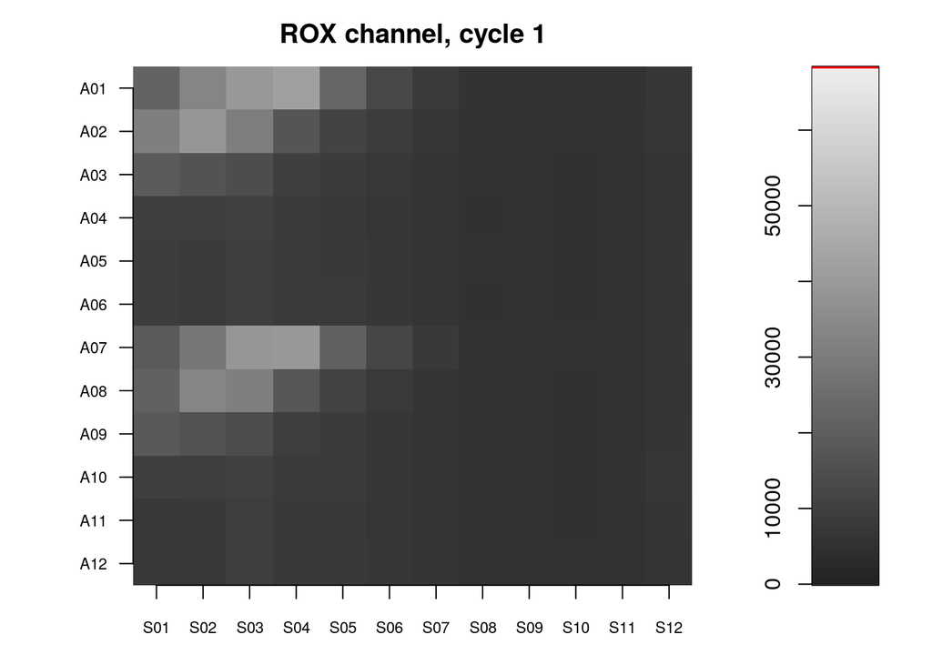

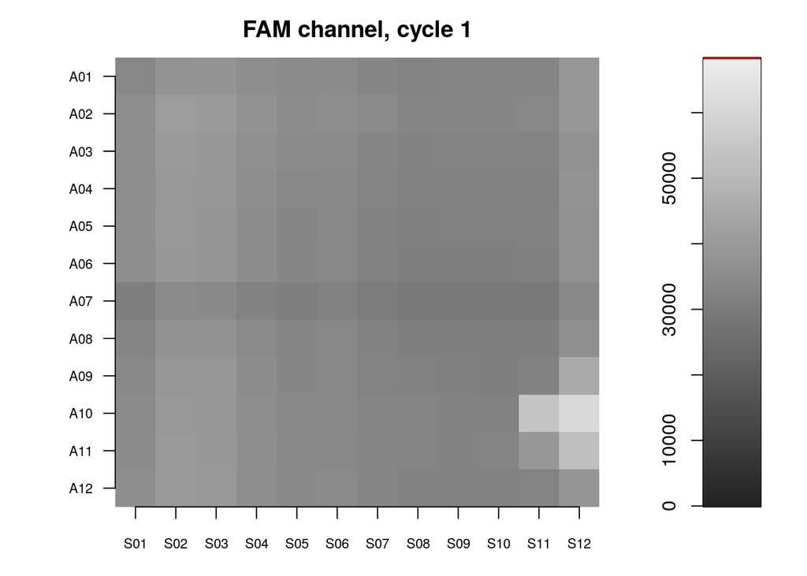

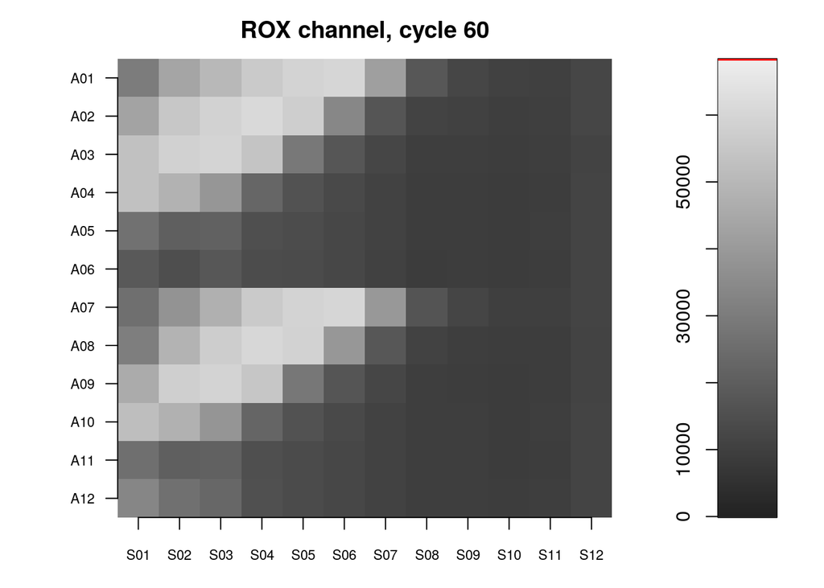

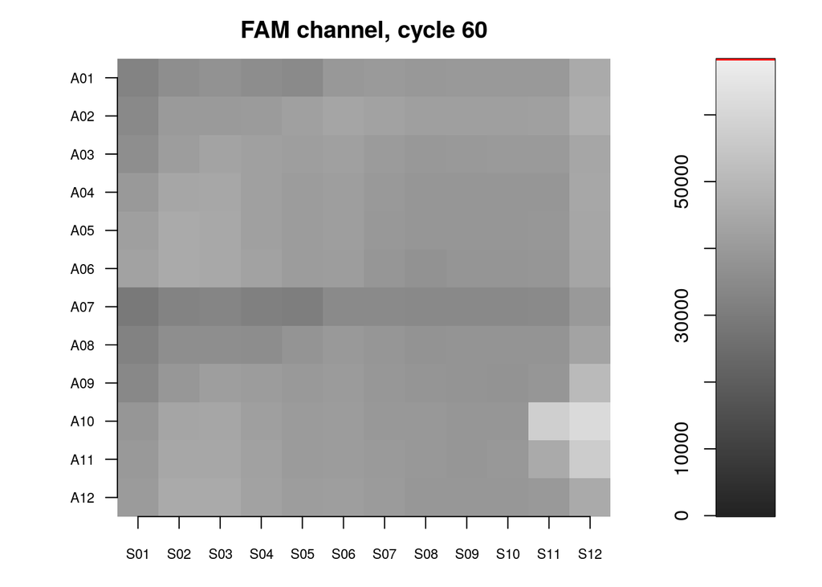

```r
plot_raw_data_heatmaps(all.df, min=0, max=65000)
```

First we plot the raw kinetics observed in all the reaction chambers

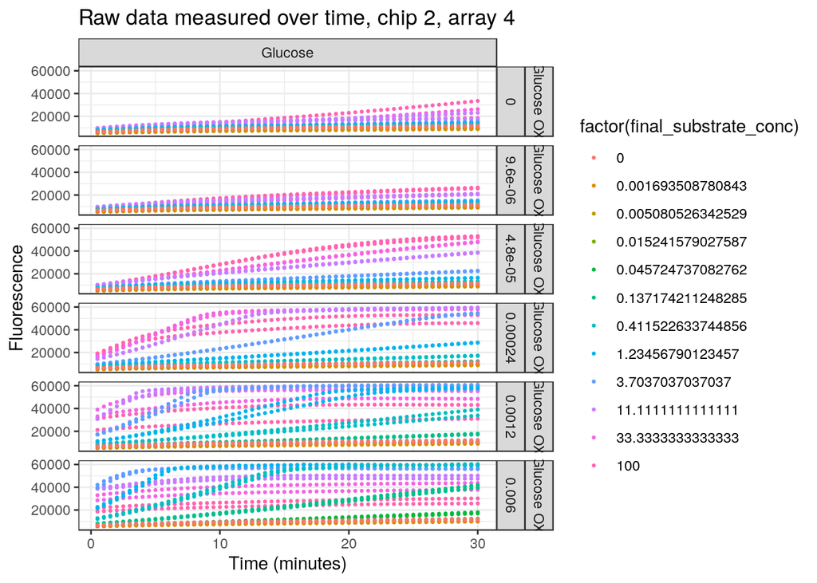

```r
ggplot(all.df, aes(x=minutes, y=rox_value, color=factor(final_substrate_conc)))+
    theme_bw() +
    geom_point(cex=0.5) +
    ggtitle(sprintf('Raw data measured over time, chip %s, array %s', CHIP_NUMBER, ARRAY_NUMBER)) +
    xlab('Time (minutes)') +
    ylab('Fluorescence') +
    facet_grid(cols=vars(sample_substrate), rows=vars(assay_enzyme, final_enzyme_conc))
```

Subtract fluorescence from the no enzyme control

```r
# remove fluorescence from the no enzyme control
all.df <- subtract_no_enz_fluorescence(all.df)

head(all.df)
```

```
##   assay_well sample_well assay_enzyme final_enzyme_conc final_enzyme_unit
## 1        A01         S12   Glucose OX           6.0e-03             mg/ml
## 2        A03         S12   Glucose OX           2.4e-04             mg/ml
## 3        A04         S12   Glucose OX           4.8e-05             mg/ml
## 4        A02         S12   Glucose OX           1.2e-03             mg/ml
## 6        A05         S12   Glucose OX           9.6e-06             mg/ml
## 7        A07         S12   Glucose OX           6.0e-03             mg/ml
##   sample_substrate final_substrate_conc final_substrate_unit minutes
## 1          Glucose                    0                   mM     0.5
## 2          Glucose                    0                   mM     0.5
## 3          Glucose                    0                   mM     0.5
## 4          Glucose                    0                   mM     0.5
## 6          Glucose                    0                   mM     0.5
## 7          Glucose                    0                   mM     0.5
##   repeat_num rox_value_norm final_substrate_norm_unit
## 1          1            316                        mM
## 2          1             22                        mM
## 3          1            -26                        mM
## 4          1            587                        mM
## 6          1             97                        mM
## 7          2            177                        mM
```

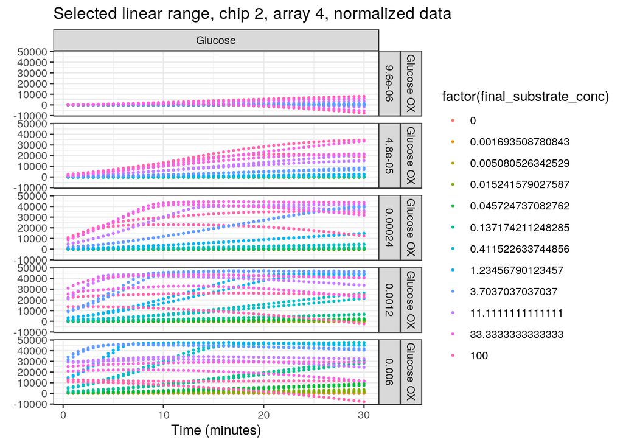

```r
in_data <- all.df
ggplot(in_data, aes(x=minutes, y=rox_value_norm, color=factor(final_substrate_conc)))+
    theme_bw() +
    geom_point(cex=0.5) +
    ggtitle(sprintf('Selected linear range, chip %s, array %s, normalized data', CHIP_NUMBER, ARRAY_NUMBER)) +
    xlab('Time (minutes)') +
    ylab(sprintf('Resorufin concentration (%s)', unique(in_data$resorufin_value_norm_unit))) +
    facet_grid(cols=vars(sample_substrate), rows=vars(assay_enzyme, final_enzyme_conc))
```

These look quite horrible. That is because the fluorescecne of the no enzyme control increases with time combined with the fact that some samples maxed out the instrument in terms of intensity, so when normalizing one gets this decreasing slope. This should be fine, however, as we will only use initial rates for the “best” enzyme concentration, so the sagging part of the lines will not be analyzed.

Convert fluorescence to concentration of product using standard curve

```r
concentration.df <- fluorescence_to_concentration(all.df, chip_type='flex_six')

head(concentration.df)
```

```
##   assay_well sample_well assay_enzyme final_enzyme_conc final_enzyme_unit
## 1        A01         S12   Glucose OX           6.0e-03             mg/ml
## 2        A03         S12   Glucose OX           2.4e-04             mg/ml
## 3        A04         S12   Glucose OX           4.8e-05             mg/ml
## 4        A02         S12   Glucose OX           1.2e-03             mg/ml
## 6        A05         S12   Glucose OX           9.6e-06             mg/ml
## 7        A07         S12   Glucose OX           6.0e-03             mg/ml
##   sample_substrate final_substrate_conc final_substrate_unit minutes
## 1          Glucose                    0                   mM     0.5
## 2          Glucose                    0                   mM     0.5
## 3          Glucose                    0                   mM     0.5
## 4          Glucose                    0                   mM     0.5
## 6          Glucose                    0                   mM     0.5
## 7          Glucose                    0                   mM     0.5
##   repeat_num final_substrate_norm_unit resorufin_value_norm
## 1          1                        mM           0.09382518
## 2          1                        mM          -0.14194066
## 3          1                        mM          -0.18043304
## 4          1                        mM           0.31114675
## 6          1                        mM          -0.08179631
## 7          2                        mM          -0.01764234
##   resorufin_value_norm_unit
## 1                        uM
## 2                        uM
## 3                        uM
## 4                        uM
## 6                        uM
## 7                        uM
```

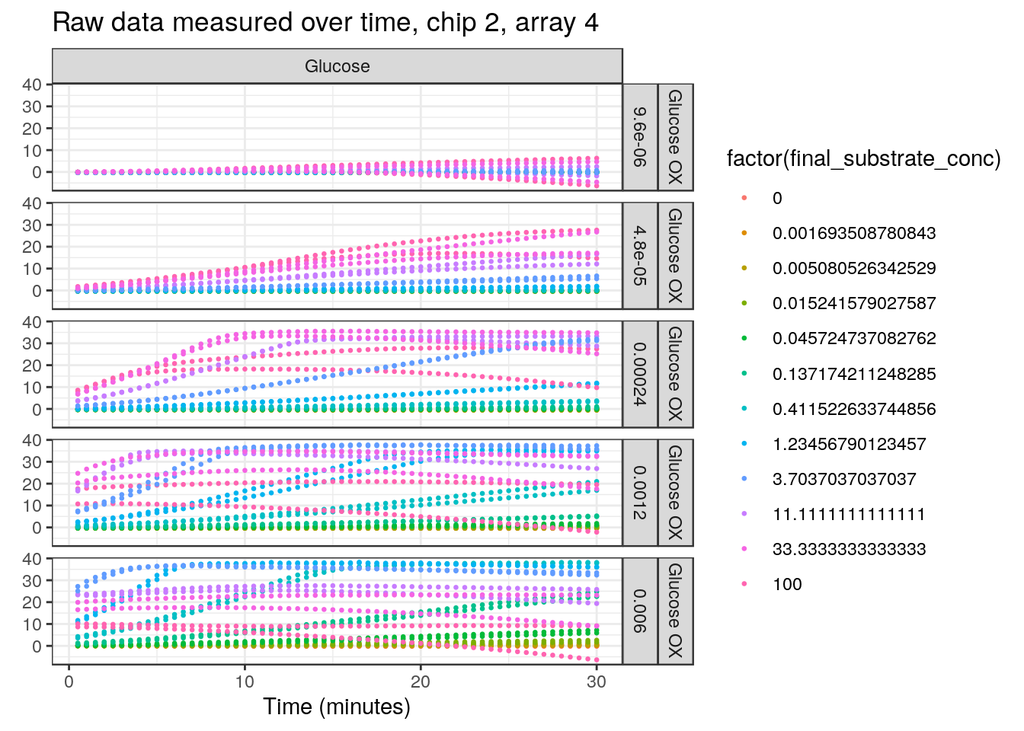

```r
in_data <- concentration.df
ggplot(in_data, aes(x=minutes, y=resorufin_value_norm, color=factor(final_substrate_conc)))+
    theme_bw() +
    geom_point(cex=0.5) +
    ggtitle(sprintf('Raw data measured over time, chip %s, array %s', CHIP_NUMBER, ARRAY_NUMBER)) +
    xlab('Time (minutes)') +
    ylab(sprintf('Resorufin concentration (%s)', unique(in_data$resorufin_value_unit))) +
    facet_grid(cols=vars(sample_substrate), rows=vars(assay_enzyme, final_enzyme_conc))
```

Remove substrate concentrations where no activity is seen ## New block ##

```r
# Remove bad enzyme-substrate combinations (low concentrations where no activity is seen)
concentration.df <- trim_data_low_range(concentration.df, tolerance_at_zero=TOLERANCE_AT_ZERO)
# look at the data
head(concentration.df)
```

```
## # A tibble: 6 x 13
## # Groups:   assay_well [12]
##   assay_well sample_well assay_enzyme final_enzyme_co… final_enzyme_un…
##   <fct>      <fct>       <fct>                   <dbl> <chr>
## 1 A01        S01         Glucose OX              0.006 mg/ml
## 2 A01        S01         Glucose OX              0.006 mg/ml
## 3 A01        S01         Glucose OX              0.006 mg/ml
## 4 A01        S01         Glucose OX              0.006 mg/ml
## 5 A01        S01         Glucose OX              0.006 mg/ml
## 6 A01        S01         Glucose OX              0.006 mg/ml
## # … with 8 more variables: sample_substrate <fct>,
## #   final_substrate_conc <dbl>, final_substrate_unit <fct>, minutes <dbl>,
## #   repeat_num <int>, final_substrate_norm_unit <fct>,
## #   resorufin_value_norm <dbl>, resorufin_value_norm_unit <chr>
```

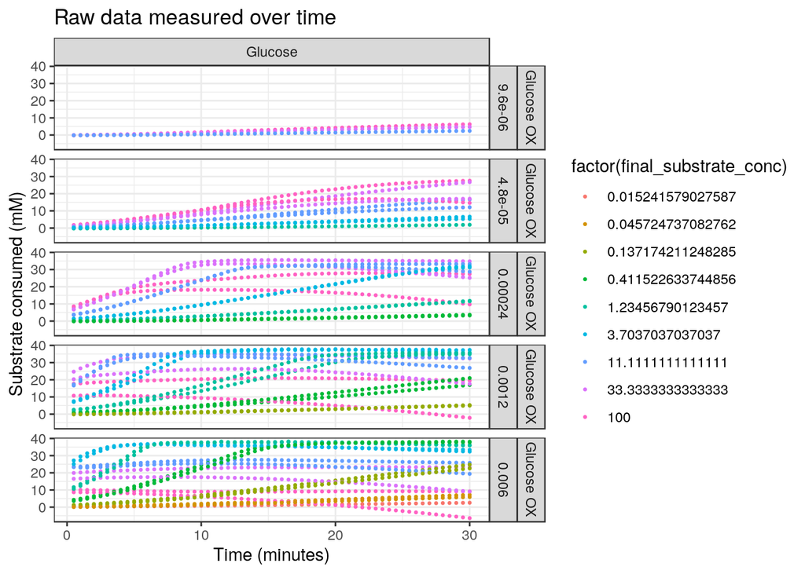

```r
# plot it
in_data <- concentration.df
ggplot(in_data, aes(x=minutes, y=resorufin_value_norm, color=factor(final_substrate_conc)))+
    theme_bw() +
    geom_point(cex=0.5) +
    ggtitle('Raw data measured over time') +
    xlab('Time (minutes)') +
    ylab(sprintf('Substrate consumed (%s)', unique(in_data$final_substrate_norm_unit))) +
    facet_grid(cols=vars(sample_substrate), rows=vars(assay_enzyme, final_enzyme_conc))
```

Make a subset which should be the linear range, plot again

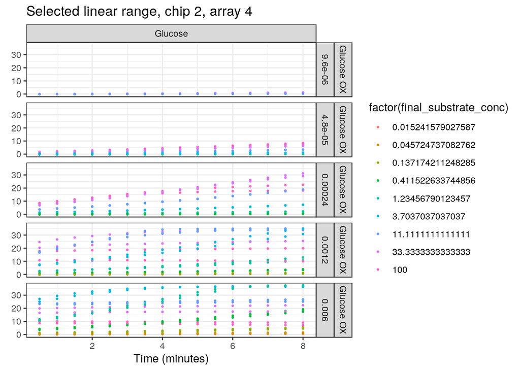

```r
all.df.slope.subset <- concentration.df[concentration.df$minutes >= SLOPE_FIRST_TIMEPOINT & concentration.df$minutes <= SLOPE_LAST_TIMEPOINT, ]

in_data <- all.df.slope.subset
ggplot(in_data, aes(x=minutes, y=resorufin_value_norm, color=factor(final_substrate_conc)))+
    theme_bw() +
    geom_point(cex=0.5) +
    ggtitle(sprintf('Selected linear range, chip %s, array %s', CHIP_NUMBER, ARRAY_NUMBER)) +
    xlab('Time (minutes)') +
    ylab(sprintf('Resorufin concentration (%s)', unique(in_data$resorufin_value_unit))) +
    facet_grid(cols=vars(sample_substrate), rows=vars(assay_enzyme, final_enzyme_conc))
```

Fit a linear regression for all data between the first and last points to get the slope.

```r
# Fit a linear regression for all data between the first and last points to get the slope.
slopes.df <- compute_slopes(all.df.slope.subset)

head(slopes.df)
```

```
## # A tibble: 6 x 13
## # Groups:   assay_well, sample_well, assay_enzyme, final_enzyme_conc,
## #   final_enzyme_unit, sample_substrate, final_substrate_conc,
## #   final_substrate_unit [6]
##   assay_well sample_well assay_enzyme final_enzyme_co… final_enzyme_un…
##   <fct>      <fct>       <fct>                   <dbl> <chr>
## 1 A01        S01         Glucose OX              0.006 mg/ml
## 2 A01        S02         Glucose OX              0.006 mg/ml
## 3 A01        S03         Glucose OX              0.006 mg/ml
## 4 A01        S04         Glucose OX              0.006 mg/ml
## 5 A01        S05         Glucose OX              0.006 mg/ml
## 6 A01        S06         Glucose OX              0.006 mg/ml
## # … with 8 more variables: sample_substrate <fct>,
## #   final_substrate_conc <dbl>, final_substrate_unit <fct>,
## #   repeat_num <int>, slope <dbl>, slope_unit <chr>, r2 <dbl>, corr <dbl>
```

```r
tail(slopes.df)
```

```
## # A tibble: 6 x 13
## # Groups:   assay_well, sample_well, assay_enzyme, final_enzyme_conc,
## #   final_enzyme_unit, sample_substrate, final_substrate_conc,
## #   final_substrate_unit [6]
##   assay_well sample_well assay_enzyme final_enzyme_co… final_enzyme_un…
##   <fct>      <fct>       <fct>                   <dbl> <chr>
## 1 A09        S05         Glucose OX           0.00024  mg/ml
## 2 A09        S06         Glucose OX           0.00024  mg/ml
## 3 A10        S01         Glucose OX           0.000048 mg/ml
## 4 A10        S02         Glucose OX           0.000048 mg/ml
## 5 A10        S03         Glucose OX           0.000048 mg/ml
## 6 A10        S04         Glucose OX           0.000048 mg/ml
## # … with 8 more variables: sample_substrate <fct>,
## #   final_substrate_conc <dbl>, final_substrate_unit <fct>,
## #   repeat_num <int>, slope <dbl>, slope_unit <chr>, r2 <dbl>, corr <dbl>
```

A look at the slope data as a heatmap and assess the fit of the linear model.

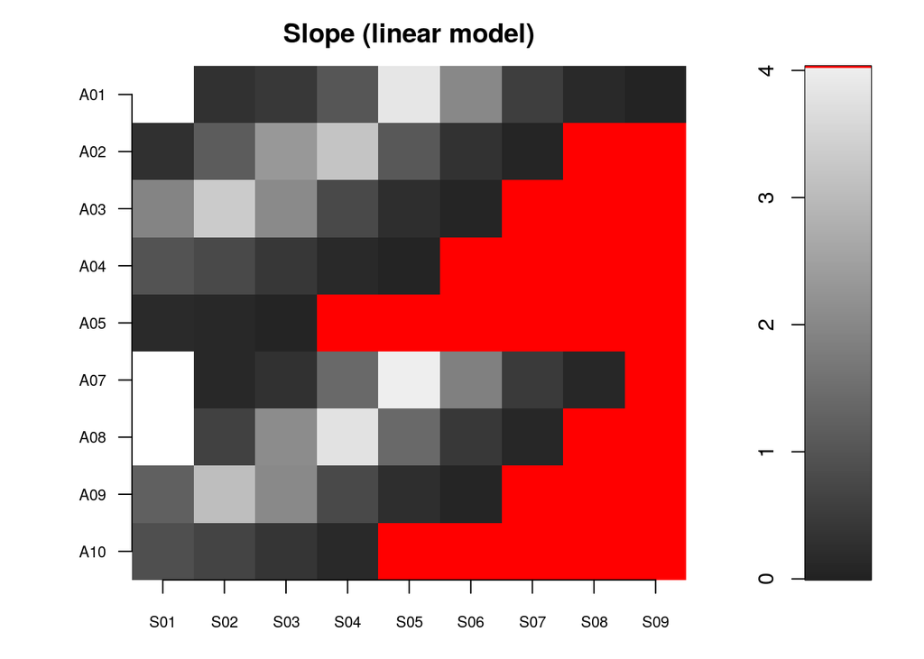

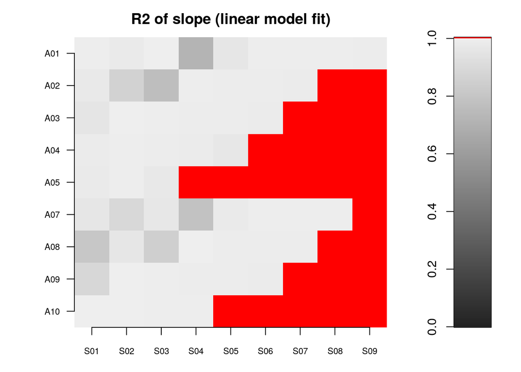

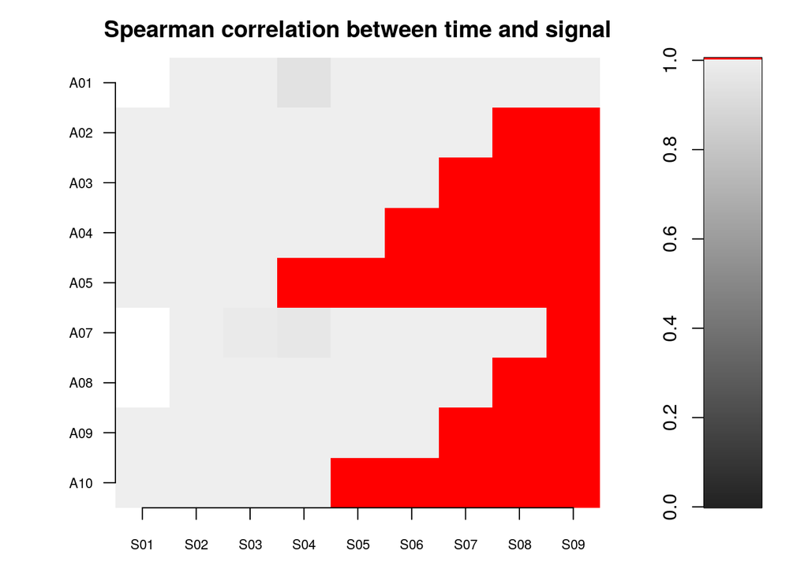

```r
plot_slope_data_heatmaps(slopes.df)
```

Remove all enzyme concentrations that have poor R2 values (below a set cutoff)

```r
bundled.slopes.nonegs.df <- filter_r2(slopes.df, r2_cutoff=R2_CUTOFF, corr_cutoff=CORR_CUTOFF)


head(bundled.slopes.nonegs.df)
```

```
## # A tibble: 6 x 10
## # Groups:   assay_well, final_enzyme_conc, repeat_num, assay_enzyme,
## #   sample_substrate [6]
##   assay_well assay_enzyme final_enzyme_co… final_enzyme_un…
##   <fct>      <fct>                   <dbl> <list>
## 1 A01        Glucose OX           0.006    <chr [9]>
## 2 A02        Glucose OX           0.00120  <chr [7]>
## 3 A03        Glucose OX           0.00024  <chr [6]>
## 4 A04        Glucose OX           0.000048 <chr [5]>
## 5 A07        Glucose OX           0.006    <chr [8]>
## 6 A08        Glucose OX           0.00120  <chr [7]>
## # … with 6 more variables: sample_substrate <fct>,
## #   final_substrate_conc <list>, final_substrate_unit <list>,
## #   repeat_num <int>, slope <list>, slope_unit <list>
```

Calculate spearman correlation between substrate concentration and the measured slope (the kinetic slope), the idea being that we expect higher substrate concentraions to lead to a steeper slopes.

```r
bundled.slopes.nonegs.spearman.df <- calculate_slope_and_substrate_correlation(bundled.slopes.nonegs.df)

# look at the data
head(bundled.slopes.nonegs.spearman.df)
```

```
## # A tibble: 6 x 12
## # Groups:   assay_well, final_enzyme_conc, repeat_num, assay_enzyme,
## #   sample_substrate [6]
##   assay_well assay_enzyme final_enzyme_co… final_enzyme_un…
##   <fct>      <fct>                   <dbl> <list>
## 1 A01        Glucose OX           0.006    <chr [9]>
## 2 A02        Glucose OX           0.00120  <chr [7]>
## 3 A03        Glucose OX           0.00024  <chr [6]>
## 4 A04        Glucose OX           0.000048 <chr [5]>
## 5 A07        Glucose OX           0.006    <chr [8]>
## 6 A08        Glucose OX           0.00120  <chr [7]>
## # … with 8 more variables: sample_substrate <fct>,
## #   final_substrate_conc <list>, final_substrate_unit <list>,
## #   repeat_num <int>, slope <list>, slope_unit <list>,
## #   slope_spearman_pval <dbl>, slope_spearman_rho <dbl>
```

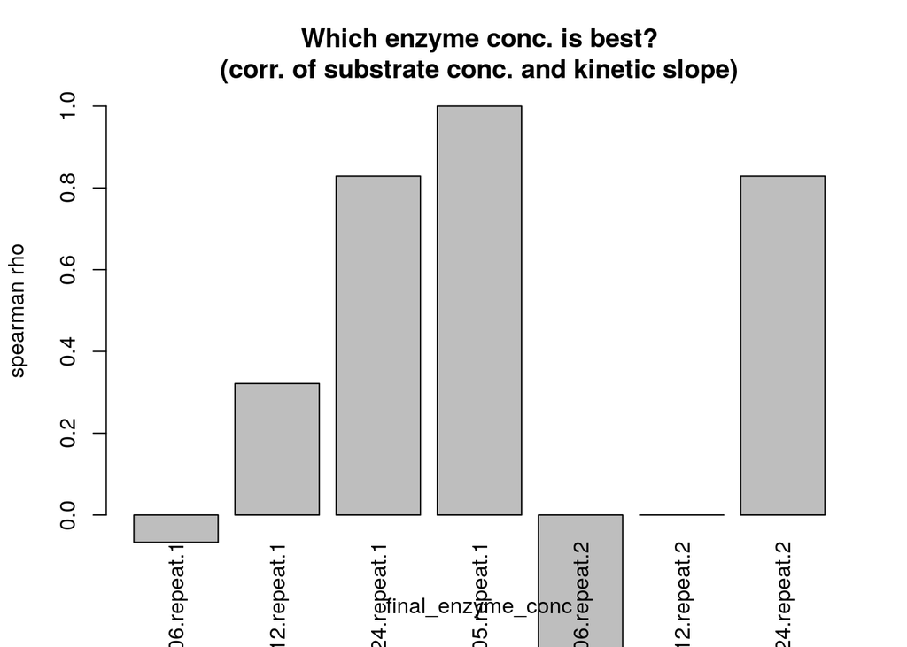

```r
# plot it
barplot(bundled.slopes.nonegs.spearman.df$slope_spearman_rho,
        names=interaction(bundled.slopes.nonegs.spearman.df$final_enzyme_conc, c('repeat'), bundled.slopes.nonegs.spearman.df$repeat_num),
        ylim=c(0, 1),
        xlab='final_enzyme_conc',
        ylab='spearman rho',
        main='Which enzyme conc. is best?\n(corr. of substrate conc. and kinetic slope)',
        las=3)
```

```r
bundled.slopes.nonegs.spearman.max.df <- select_best_samples(bundled.slopes.nonegs.spearman.df)

# look at the data
head(bundled.slopes.nonegs.spearman.max.df)
```

```
## # A tibble: 2 x 12
## # Groups:   assay_well, final_enzyme_conc, repeat_num, assay_enzyme,
## #   sample_substrate [2]
##   assay_well assay_enzyme final_enzyme_co… final_enzyme_un…
##   <fct>      <fct>                   <dbl> <list>
## 1 A03        Glucose OX            0.00024 <chr [6]>
## 2 A09        Glucose OX            0.00024 <chr [6]>
## # … with 8 more variables: sample_substrate <fct>,
## #   final_substrate_conc <list>, final_substrate_unit <list>,
## #   repeat_num <int>, slope <list>, slope_unit <list>,
## #   slope_spearman_pval <dbl>, slope_spearman_rho <dbl>
```

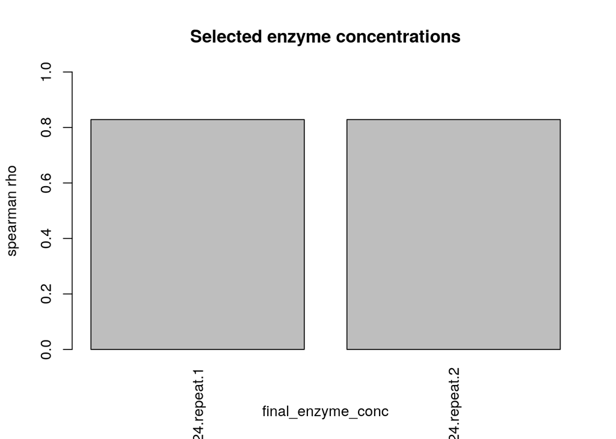

```r
# plot it
barplot(bundled.slopes.nonegs.spearman.max.df$slope_spearman_rho,
        names=interaction(bundled.slopes.nonegs.spearman.max.df$final_enzyme_conc, c('repeat'), bundled.slopes.nonegs.spearman.max.df$repeat_num),
        ylim=c(0, 1),
        xlab='final_enzyme_conc',
        ylab='spearman rho',
        main='Selected enzyme concentrations',
        las=3)
```

Unbundle the dataset (turn the lists into column values again)

```r
bundled.slopes.nonegs.spearman.max.filtered.unbundled.df <- unbundle_data(bundled.slopes.nonegs.spearman.max.df)

head(bundled.slopes.nonegs.spearman.max.filtered.unbundled.df)
```

```
## # A tibble: 6 x 9
##   assay_enzyme final_enzyme_co… final_enzyme_un… sample_substrate
##   <fct>                   <dbl> <chr>            <fct>
## 1 Glucose OX            0.00024 mg/ml            Glucose
## 2 Glucose OX            0.00024 mg/ml            Glucose
## 3 Glucose OX            0.00024 mg/ml            Glucose
## 4 Glucose OX            0.00024 mg/ml            Glucose
## 5 Glucose OX            0.00024 mg/ml            Glucose
## 6 Glucose OX            0.00024 mg/ml            Glucose
## # … with 5 more variables: final_substrate_conc <dbl>,
## #   final_substrate_unit <fct>, repeat_num <int>, slope <dbl>,
## #   slope_unit <chr>
```

Need to convert from uM per minute to micro moles per minute

```r
final.data.moles.df <- concentration_to_moles(bundled.slopes.nonegs.spearman.max.filtered.unbundled.df, chip_type='flex_six')

head(final.data.moles.df)
```

```
##   assay_enzyme final_enzyme_conc final_enzyme_unit sample_substrate
## 1   Glucose OX           0.00024             mg/ml          Glucose
## 2   Glucose OX           0.00024             mg/ml          Glucose
## 3   Glucose OX           0.00024             mg/ml          Glucose
## 4   Glucose OX           0.00024             mg/ml          Glucose
## 5   Glucose OX           0.00024             mg/ml          Glucose
## 6   Glucose OX           0.00024             mg/ml          Glucose
##   final_substrate_conc final_substrate_unit repeat_num      slope
## 1          100.0000000                   mM          1 1.93307703
## 2           33.3333333                   mM          1 3.32992830
## 3           11.1111111                   mM          1 2.04033445
## 4            3.7037037                   mM          1 0.78869286
## 5            1.2345679                   mM          1 0.24655880
## 6            0.4115226                   mM          1 0.06899854
##   slope_unit activity_moles activity_moles_unit
## 1  uM min^-1   1.714639e-08         umol min^-1
## 2  uM min^-1   2.953646e-08         umol min^-1
## 3  uM min^-1   1.809777e-08         umol min^-1
## 4  uM min^-1   6.995706e-09         umol min^-1
## 5  uM min^-1   2.186977e-09         umol min^-1
## 6  uM min^-1   6.120170e-10         umol min^-1
```

Normalize to per mg protein

```r
final.data.moles.protein.df <- normalize_to_protein(final.data.moles.df, chip_type='flex_six')

head(final.data.moles.protein.df)
```

```
##   assay_enzyme final_enzyme_conc final_enzyme_unit sample_substrate
## 1   Glucose OX           0.00024             mg/ml          Glucose
## 2   Glucose OX           0.00024             mg/ml          Glucose
## 3   Glucose OX           0.00024             mg/ml          Glucose
## 4   Glucose OX           0.00024             mg/ml          Glucose
## 5   Glucose OX           0.00024             mg/ml          Glucose
## 6   Glucose OX           0.00024             mg/ml          Glucose
##   final_substrate_conc final_substrate_unit repeat_num      slope
## 1          100.0000000                   mM          1 1.93307703
## 2           33.3333333                   mM          1 3.32992830
## 3           11.1111111                   mM          1 2.04033445
## 4            3.7037037                   mM          1 0.78869286
## 5            1.2345679                   mM          1 0.24655880
## 6            0.4115226                   mM          1 0.06899854
##   slope_unit activity_moles activity_moles_unit activity_moles_protein
## 1  uM min^-1   1.714639e-08         umol min^-1              8.0544876
## 2  uM min^-1   2.953646e-08         umol min^-1             13.8747012
## 3  uM min^-1   1.809777e-08         umol min^-1              8.5013935
## 4  uM min^-1   6.995706e-09         umol min^-1              3.2862203
## 5  uM min^-1   2.186977e-09         umol min^-1              1.0273283
## 6  uM min^-1   6.120170e-10         umol min^-1              0.2874939
##   activity_moles_protein_unit
## 1           umol min^-1 mg^-1
## 2           umol min^-1 mg^-1
## 3           umol min^-1 mg^-1
## 4           umol min^-1 mg^-1
## 5           umol min^-1 mg^-1
## 6           umol min^-1 mg^-1
```

Make a plot of the new values

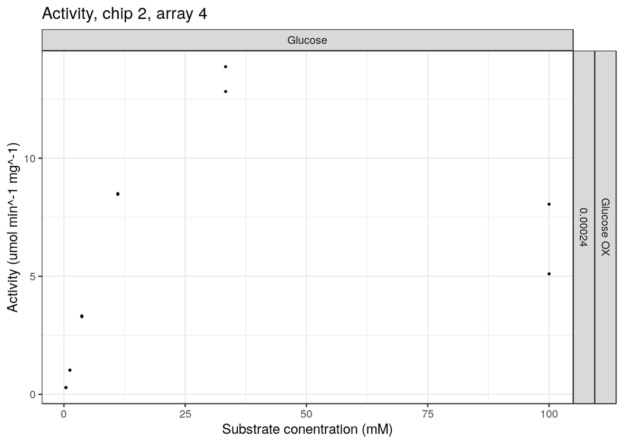

```r
# plot it
in_data <- final.data.moles.protein.df
ggplot(in_data, aes(x=final_substrate_conc, y=activity_moles_protein))+
    theme_bw() +
    geom_point(cex=0.5) +
    ggtitle(sprintf('Activity, chip %s, array %s', CHIP_NUMBER, ARRAY_NUMBER)) +
    xlab(sprintf('Substrate conentration (%s)', unique(sample.df$sample_substrate_unit))) +
    ylab(sprintf('Activity (%s)', unique(in_data$activity_moles_protein_unit))) +
    facet_grid(cols=vars(sample_substrate), rows=vars(assay_enzyme, final_enzyme_conc))
```

Trim off bad values at very high substrate concentrations ## Block changed ##

```r
# Remove bad values (low concentrations where no activity is seen, and high values where activity drops below max)
final.data.filtered.both.df <- trim_data_top_range(final.data.moles.protein.df, tolerance_at_max=TOLERANCE_AT_VMAX)

# look at the data
head(final.data.filtered.both.df)
```

```
## # A tibble: 6 x 11
## # Groups:   final_enzyme_conc, final_enzyme_unit, assay_enzyme,
## #   sample_substrate, repeat_num [2]
##   assay_enzyme final_enzyme_co… final_enzyme_un… sample_substrate
##   <fct>                   <dbl> <chr>            <fct>
## 1 Glucose OX            0.00024 mg/ml            Glucose
## 2 Glucose OX            0.00024 mg/ml            Glucose
## 3 Glucose OX            0.00024 mg/ml            Glucose
## 4 Glucose OX            0.00024 mg/ml            Glucose
## 5 Glucose OX            0.00024 mg/ml            Glucose
## 6 Glucose OX            0.00024 mg/ml            Glucose
## # … with 7 more variables: final_substrate_conc <dbl>,
## #   final_substrate_unit <fct>, repeat_num <int>, activity_moles <dbl>,
## #   activity_moles_unit <chr>, activity_moles_protein <dbl>,
## #   activity_moles_protein_unit <chr>
```

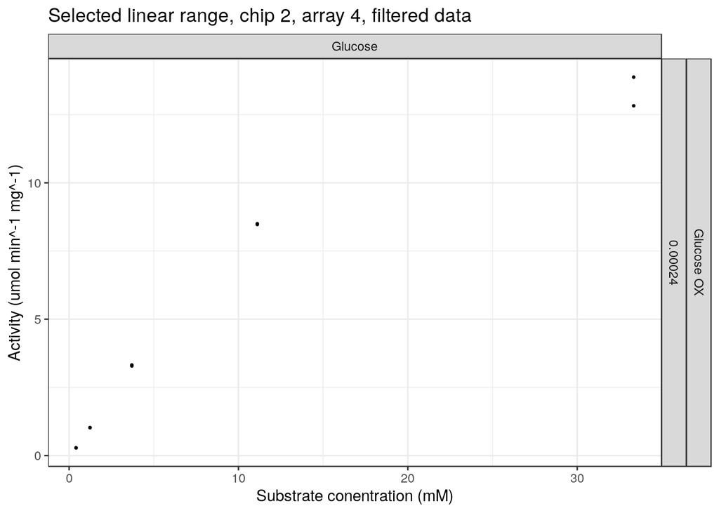

```r
# plot it
in_data <- final.data.filtered.both.df
ggplot(in_data, aes(x=final_substrate_conc, y=activity_moles_protein))+
    theme_bw() +
    geom_point(cex=0.5) +
    ggtitle(sprintf('Selected linear range, chip %s, array %s, filtered data', CHIP_NUMBER, ARRAY_NUMBER)) +
    xlab(sprintf('Substrate conentration (%s)', unique(sample.df$sample_substrate_unit))) +
    ylab(sprintf('Activity (%s)', unique(in_data$activity_moles_protein_unit))) +
    facet_grid(cols=vars(sample_substrate), rows=vars(assay_enzyme, final_enzyme_conc))
```

Export for future use

```r
write.table(final.data.filtered.both.df, file=paste(FINAL, THIS_PROJECT_FOLDER, sprintf('%s_flex_six_chip_%s_array_%s_final_data.tsv', gsub(' ', '_', unique(all.df$assay_enzyme)), CHIP_NUMBER, ARRAY_NUMBER), sep='/'), sep='\t', row.names=FALSE)
```

Plot slope vs substrate concentration, estimate Km and Vmax by fitting to the Michaelis-Menten equation

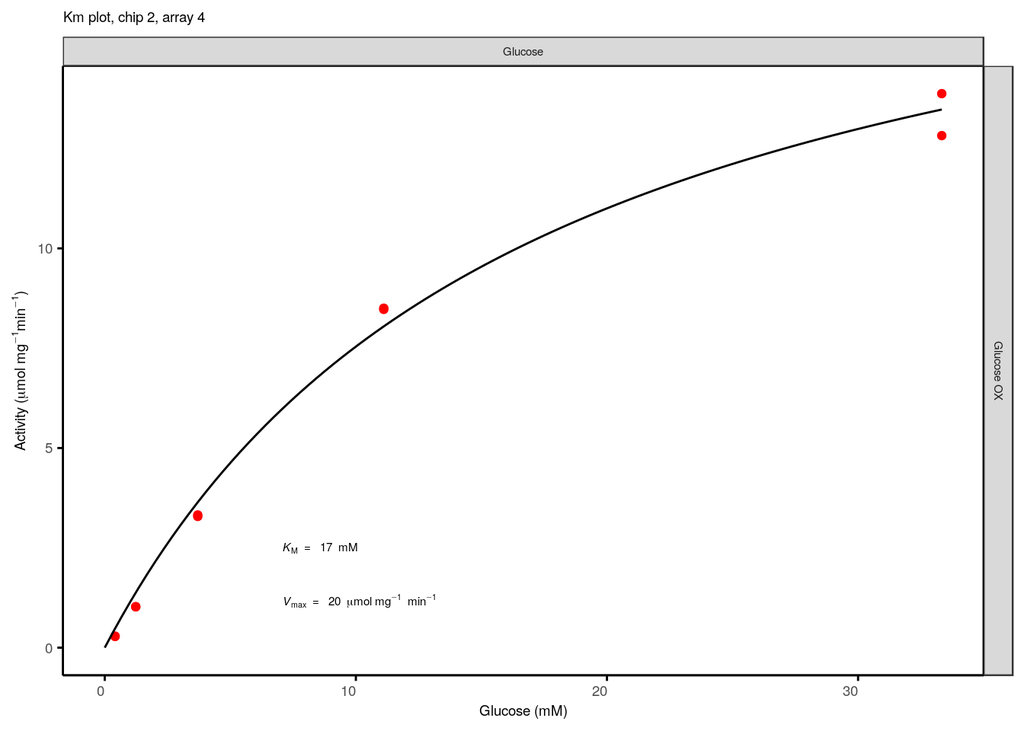

```r
kinetic_data <- calculate_kinetics(final.data.filtered.both.df)
mm_fit.df <- data.frame(xFit=kinetic_data$xFit, yFit=kinetic_data$yFit)
km <- kinetic_data[[3]]
vmax <- kinetic_data[[4]]


in_data <- final.data.filtered.both.df

p1 <- ggplot(in_data, aes(x=final_substrate_conc, y=activity_moles_protein))+
    theme_bw() +
    ggplot_theme +
    geom_point(cex=1.5, fill='red', color='red') +
    geom_line(data=mm_fit.df, aes(x=xFit, y=yFit)) +
    ggtitle(sprintf('Km plot, chip %s, array %s', CHIP_NUMBER, ARRAY_NUMBER)) +
    xlab(sprintf('%s (%s)', unique(in_data$sample_substrate), unique(in_data$final_substrate_unit))) +
    ylab( expression(paste('Activity (', mu, 'mol mg'^{-1}, 'min'^{-1}, ')') ) ) +

    annotate("text",
            x = min(in_data$final_substrate_conc) + max(in_data$final_substrate_conc)*0.2,
            y = min(in_data$activity_moles_protein) + max(in_data$activity_moles_protein)*0.05,
            label = as.expression(bquote(italic(V)[max] ~ '=' ~ .(formatC(vmax, format='g', digits=2)) ~ mu * 'mol mg'^{-1} ~ 'min'^{-1})),
            size=2,
            hjust=0,
            vjust=0) +

    annotate("text",
             x = min(in_data$final_substrate_conc) + max(in_data$final_substrate_conc)*0.2,
             y = min(in_data$activity_moles_protein) + max(in_data$activity_moles_protein)*0.15,
             label = as.expression(bquote(italic(K)[M] ~ '=' ~ .(formatC(km, format='g', digits=2)) ~ 'mM')),
             size=2,
             hjust=0,
             vjust=0) +

    facet_grid(cols=vars(sample_substrate), rows=vars(assay_enzyme))


p1
```

```r
# save the figure
fname = paste(FIGURES, sprintf('%s_flex_six_chip_%s_array_%s_Km_plot.pdf', gsub(' ', '_', unique(all.df$assay_enzyme)), CHIP_NUMBER, ARRAY_NUMBER), sep='/')
ggsave(filename=fname, plot=p1, width = 65*length(unique(sample.df$sample_substrate)), height = 50*length(unique(assay.df$assay_enzyme)), units=c('mm'))
# save the km and kcat
```